```python
import warnings
warnings.filterwarnings('ignore')

# Libraries to help with reading and manipulating data
import numpy as np
import pandas as pd

# Libraries to help with data visualization
import matplotlib.pyplot as plt
%matplotlib inline
import seaborn as sns

# Libraries to split data, impute missing values
from sklearn.model_selection import train_test_split
from sklearn.impute import SimpleImputer

# Libraries to import decision tree classifier and different ensemble classifiers
from sklearn.ensemble import BaggingClassifier
from sklearn.ensemble import RandomForestClassifier
from sklearn.ensemble import AdaBoostClassifier, GradientBoostingClassifier
from xgboost import XGBClassifier
from sklearn.ensemble import StackingClassifier
from sklearn.tree import DecisionTreeClassifier

# Libtune to tune model, get different metric scores
from sklearn import metrics
from sklearn.metrics import confusion_matrix, classification_report, accuracy_score, precision_score, recall_score
from sklearn.metrics import f1_score, roc_auc_score
from sklearn.model_selection import GridSearchCV
```

# Load data

```python
df=pd.read_csv("bank-full.csv")
```

```python
df.head()
```

|  | age | job | marital | education | default | balance | housing | loan | contact | day | month | duration | campaign | pdays | previous | poutcome | Target |
| --- | --- | --- | --- | --- | --- | --- | --- | --- | --- | --- | --- | --- | --- | --- | --- | --- | --- |
| 0 | 58 | management | married | tertiary | no | 2143 | yes | no | unknown | 5 | may | 261 | 1 | -1 | 0 | unknown | no |
| 1 | 44 | technician | single | secondary | no | 29 | yes | no | unknown | 5 | may | 151 | 1 | -1 | 0 | unknown | no |
| 2 | 33 | entrepreneur | married | secondary | no | 2 | yes | yes | unknown | 5 | may | 76 | 1 | -1 | 0 | unknown | no |
| 3 | 47 | blue-collar | married | unknown | no | 1506 | yes | no | unknown | 5 | may | 92 | 1 | -1 | 0 | unknown | no |
| 4 | 33 | unknown | single | unknown | no | 1 | no | no | unknown | 5 | may | 198 | 1 | -1 | 0 | unknown | no |

```python
df.groupby("job").mean()["balance"]
```

```
job
admin.           1135.838909
blue-collar      1078.826654
entrepreneur     1521.470074
housemaid        1392.395161
management       1763.616832
retired          1984.215106
self-employed    1647.970868
services          997.088108
student          1388.060768
technician       1252.632092
unemployed       1521.745971
unknown          1772.357639
Name: balance, dtype: float64
```

```python
df.info()
```

```
<class 'pandas.core.frame.DataFrame'>
RangeIndex: 45211 entries, 0 to 45210
Data columns (total 17 columns):
 #   Column     Non-Null Count  Dtype
---  ------     --------------  -----
 0   age        45211 non-null  int64
 1   job        45211 non-null  object
 2   marital    45211 non-null  object
 3   education  45211 non-null  object
 4   default    45211 non-null  object
 5   balance    45211 non-null  int64
 6   housing    45211 non-null  object
 7   loan       45211 non-null  object
 8   contact    45211 non-null  object
 9   day        45211 non-null  int64
 10  month      45211 non-null  object
 11  duration   45211 non-null  int64
 12  campaign   45211 non-null  int64
 13  pdays      45211 non-null  int64
 14  previous   45211 non-null  int64
 15  poutcome   45211 non-null  object
 16  Target     45211 non-null  object
dtypes: int64(7), object(10)
memory usage: 5.9+ MB
```

We See that there are no null values, there are 17 columns and 45211 observations

# Checking unique values

```python
df.nunique()
```

```
age            77
job            12
marital         3
education       4
default         2
balance      7168
housing         2
loan            2
contact         3
day            31
month          12
duration     1573
campaign       48
pdays         559
previous       41
poutcome        4
Target          2
dtype: int64
```

# Summarising the data

```python
df.describe().T
```

|  | count | mean | std | min | 25% | 50% | 75% | max |
| --- | --- | --- | --- | --- | --- | --- | --- | --- |
| age | 45211.0 | 40.936210 | 10.618762 | 18.0 | 33.0 | 39.0 | 48.0 | 95.0 |
| balance | 45211.0 | 1362.272058 | 3044.765829 | -8019.0 | 72.0 | 448.0 | 1428.0 | 102127.0 |
| day | 45211.0 | 15.806419 | 8.322476 | 1.0 | 8.0 | 16.0 | 21.0 | 31.0 |
| duration | 45211.0 | 258.163080 | 257.527812 | 0.0 | 103.0 | 180.0 | 319.0 | 4918.0 |
| campaign | 45211.0 | 2.763841 | 3.098021 | 1.0 | 1.0 | 2.0 | 3.0 | 63.0 |
| pdays | 45211.0 | 40.197828 | 100.128746 | -1.0 | -1.0 | -1.0 | -1.0 | 871.0 |
| previous | 45211.0 | 0.580323 | 2.303441 | 0.0 | 0.0 | 0.0 | 0.0 | 275.0 |

Mean and median age is close, i.e. 41 and 39

Balance has outliers, need to explpore further

Duration has outliers, need to explore further

The campaign number of contacts has outliers as well, need to explore further

Pdays and previous has outliers as well

# Unique categoriers in categoru columns

```python
#Making a list of all catrgorical variables
cat_col=['job', 'marital','education', 'default', 'housing',
       'loan', 'contact', 'month',
        'poutcome', 'Target']

#Printing number of count of each unique value in each column
for column in cat_col:
    print(df[column].value_counts())
    print('-'*50)
```

```
blue-collar      9732
management       9458
technician       7597
admin.           5171
services         4154
retired          2264
self-employed    1579
entrepreneur     1487
unemployed       1303
housemaid        1240
student           938
unknown           288
Name: job, dtype: int64
--------------------------------------------------
married     27214
single      12790
divorced     5207
Name: marital, dtype: int64
--------------------------------------------------
secondary    23202
tertiary     13301
primary       6851
unknown       1857
Name: education, dtype: int64
--------------------------------------------------
no     44396
yes      815
Name: default, dtype: int64
--------------------------------------------------
yes    25130
no     20081
Name: housing, dtype: int64
--------------------------------------------------
no     37967
yes     7244
Name: loan, dtype: int64
--------------------------------------------------
cellular     29285
unknown      13020
telephone     2906
```

[output cut: 11 more lines]

```
sep      579
mar      477
dec      214
Name: month, dtype: int64
--------------------------------------------------
unknown    36959
failure     4901
other       1840
success     1511
Name: poutcome, dtype: int64
--------------------------------------------------
no     39922
yes     5289
Name: Target, dtype: int64
--------------------------------------------------
```

Most of the customers are married with no personal loan, but with housing loans

# Converting to categories

```python
for column in cat_col:
    df[column]=df[column].astype('category')
```

```python
df.info()
```

```
<class 'pandas.core.frame.DataFrame'>
RangeIndex: 45211 entries, 0 to 45210
Data columns (total 17 columns):
 #   Column     Non-Null Count  Dtype
---  ------     --------------  -----
 0   age        45211 non-null  int64
 1   job        45211 non-null  category
 2   marital    45211 non-null  category
 3   education  45211 non-null  category
 4   default    45211 non-null  category
 5   balance    45211 non-null  int64
 6   housing    45211 non-null  category
 7   loan       45211 non-null  category
 8   contact    45211 non-null  category
 9   day        45211 non-null  int64
 10  month      45211 non-null  category
 11  duration   45211 non-null  int64
 12  campaign   45211 non-null  int64
 13  pdays      45211 non-null  int64
 14  previous   45211 non-null  int64
 15  poutcome   45211 non-null  category
 16  Target     45211 non-null  category
dtypes: category(10), int64(7)
memory usage: 2.8 MB
```

```python
def histogram_boxplot(data, feature, figsize=(12, 7), kde=False, bins=None):
    """
    Boxplot and histogram combined

    data: dataframe
    feature: dataframe column
    figsize: size of figure (default (12,7))
    kde: whether to show the density curve (default False)
    bins: number of bins for histogram (default None)
    """
    f2, (ax_box2, ax_hist2) = plt.subplots(
        nrows=2,  # Number of rows of the subplot grid= 2
        sharex=True,  # x-axis will be shared among all subplots
        gridspec_kw={"height_ratios": (0.25, 0.75)},
        figsize=figsize,
    )  # creating the 2 subplots
    sns.boxplot(
        data=data, x=feature, ax=ax_box2, showmeans=True, color="violet"
    )  # boxplot will be created and a star will indicate the mean value of the column
    sns.histplot(
        data=data, x=feature, kde=kde, ax=ax_hist2, bins=bins, palette="winter"
    ) if bins else sns.histplot(
        data=data, x=feature, kde=kde, ax=ax_hist2
    )  # For histogram
    ax_hist2.axvline(
        data[feature].mean(), color="green", linestyle="--"
    )  # Add mean to the histogram
    ax_hist2.axvline(
        data[feature].median(), color="black", linestyle="-"
    )  # Add median to the histogram
```

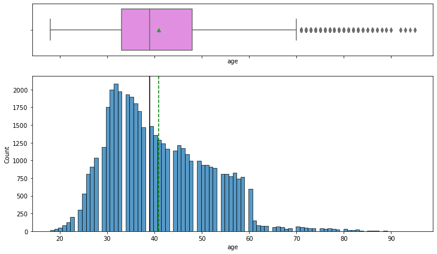

```python
histogram_boxplot(df, "age")
```

Is almost normally distibuted, but the age does have outliers

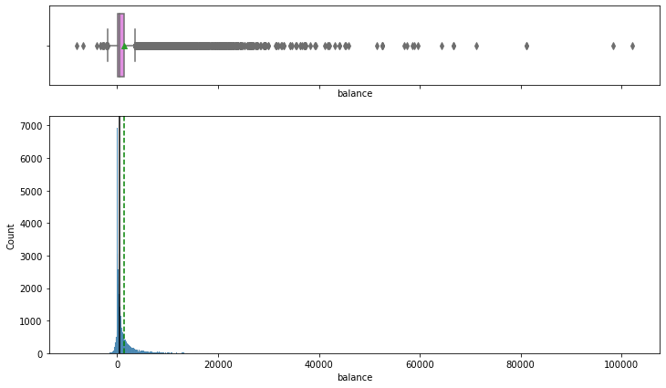

```python
histogram_boxplot(df, "balance")
```

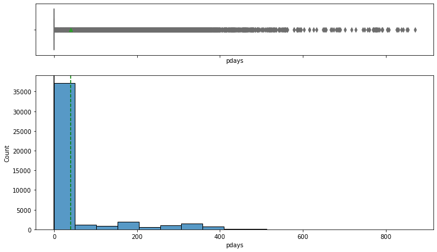

```python
histogram_boxplot(df, "pdays")
```

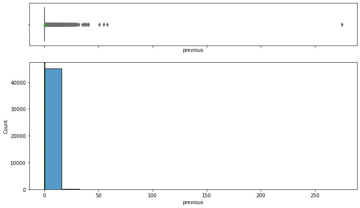

```python
histogram_boxplot(df, "previous")
```

Both Pdays and previous are not normally distributed and are skewed

# Dropping Outliers

```python
df[(df.age>80)]
```

|  | age | job | marital | education | default | balance | housing | loan | contact | day | month | duration | campaign | pdays | previous | poutcome | Target |
| --- | --- | --- | --- | --- | --- | --- | --- | --- | --- | --- | --- | --- | --- | --- | --- | --- | --- |
| 29158 | 83 | retired | married | primary | no | 425 | no | no | telephone | 2 | feb | 912 | 1 | -1 | 0 | unknown | no |
| 29322 | 83 | retired | married | tertiary | no | 6236 | no | no | cellular | 2 | feb | 283 | 2 | -1 | 0 | unknown | no |
| 31051 | 83 | retired | single | primary | no | 3349 | no | no | telephone | 12 | feb | 89 | 1 | -1 | 0 | unknown | no |
| 31055 | 85 | retired | married | primary | no | 12114 | no | no | telephone | 12 | feb | 165 | 2 | -1 | 0 | unknown | yes |
| 31069 | 90 | retired | divorced | secondary | no | 1 | no | no | cellular | 13 | feb | 152 | 3 | -1 | 0 | unknown | yes |
| ... | ... | ... | ... | ... | ... | ... | ... | ... | ... | ... | ... | ... | ... | ... | ... | ... | ... |
| 44830 | 81 | retired | married | primary | no | 1154 | no | no | telephone | 17 | sep | 231 | 1 | -1 | 0 | unknown | yes |
| 44875 | 82 | retired | divorced | primary | no | 928 | no | no | telephone | 23 | sep | 217 | 2 | 188 | 3 | other | no |
| 44892 | 89 | retired | married | primary | no | 0 | no | no | telephone | 27 | sep | 157 | 5 | -1 | 0 | unknown | no |
| 44893 | 81 | retired | divorced | primary | no | 949 | no | no | cellular | 27 | sep | 188 | 2 | 280 | 1 | other | yes |
| 45010 | 86 | retired | married | primary | no | 1255 | no | no | cellular | 14 | oct | 192 | 2 | 92 | 4 | success | no |

99 rows × 17 columns

```python
df[(df.balance>60000)]
```

|  | age | job | marital | education | default | balance | housing | loan | contact | day | month | duration | campaign | pdays | previous | poutcome | Target |
| --- | --- | --- | --- | --- | --- | --- | --- | --- | --- | --- | --- | --- | --- | --- | --- | --- | --- |
| 19420 | 59 | admin. | married | unknown | no | 64343 | no | no | cellular | 6 | aug | 45 | 4 | -1 | 0 | unknown | no |
| 19785 | 56 | management | divorced | tertiary | no | 66721 | no | no | cellular | 8 | aug | 442 | 2 | -1 | 0 | unknown | no |
| 21192 | 52 | blue-collar | married | primary | no | 66653 | no | no | cellular | 14 | aug | 109 | 3 | -1 | 0 | unknown | no |
| 26227 | 59 | management | married | tertiary | no | 98417 | no | no | telephone | 20 | nov | 145 | 5 | -1 | 0 | unknown | no |
| 39989 | 51 | management | single | tertiary | no | 102127 | no | no | cellular | 3 | jun | 90 | 1 | -1 | 0 | unknown | no |
| 41693 | 60 | retired | married | primary | no | 71188 | no | no | cellular | 6 | oct | 205 | 1 | -1 | 0 | unknown | no |
| 42558 | 84 | retired | married | secondary | no | 81204 | no | no | telephone | 28 | dec | 679 | 1 | 313 | 2 | other | yes |
| 43393 | 84 | retired | married | secondary | no | 81204 | no | no | telephone | 1 | apr | 390 | 1 | 94 | 3 | success | yes |

```python
#Dropping observaions with age over 80, there are 99 observations
df.drop(index=df[df.age>80].index,inplace=True)

#Dropping observation with balance more than 60000
df.drop(index=df[df.balance>60000].index,inplace=True)
```

# Function to perform EDA for categories

```python
def labeled_barplot(data, feature, perc=False, n=None):
    """
    Barplot with percentage at the top

    data: dataframe
    feature: dataframe column
    perc: whether to display percentages instead of count (default is False)
    n: displays the top n category levels (default is None, i.e., display all levels)
    """

    total = len(data[feature])  # length of the column
    count = data[feature].nunique()
    if n is None:
        plt.figure(figsize=(count + 1, 5))
    else:
        plt.figure(figsize=(n + 1, 5))

    plt.xticks(rotation=90, fontsize=15)
    ax = sns.countplot(
        data=data,
        x=feature,
        palette="Paired",
        order=data[feature].value_counts().index[:n].sort_values(),
    )

    for p in ax.patches:
        if perc == True:
            label = "{:.1f}%".format(
                100 * p.get_height() / total
            )  # percentage of each class of the category
        else:
            label = p.get_height()  # count of each level of the category

        x = p.get_x() + p.get_width() / 2  # width of the plot
        y = p.get_height()  # height of the plot

        ax.annotate(
            label,
            (x, y),
            ha="center",
            va="center",
            size=12,
            xytext=(0, 5),
            textcoords="offset points",
        )  # annotate the percentage

    plt.show()
```

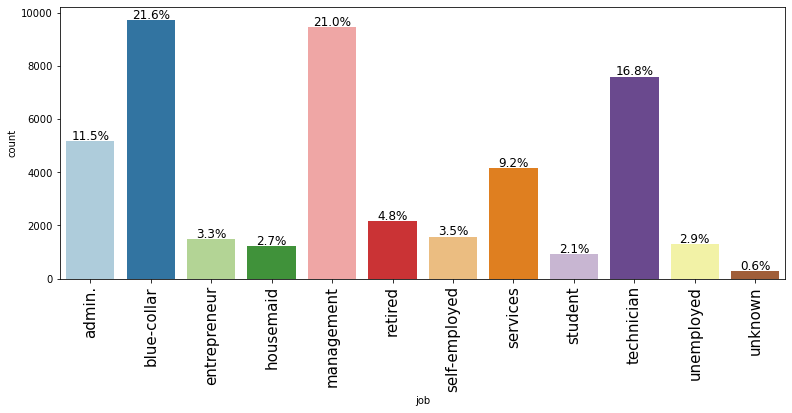

```python
labeled_barplot(df, "job", perc=True)
```

We see that the most number of customers belong to the blue collar category followed by management and technicians.

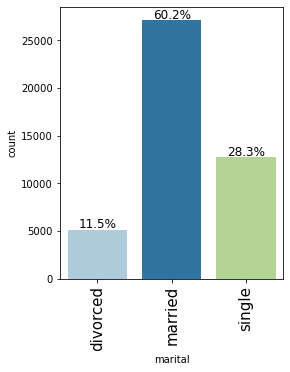

```python
labeled_barplot(df, "marital", perc=True)
```

Most of the customers, around 60.2% are married

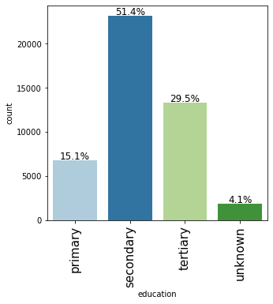

```python
labeled_barplot(df, "education", perc=True)
```

51.4% of the customers have completed secondary education.

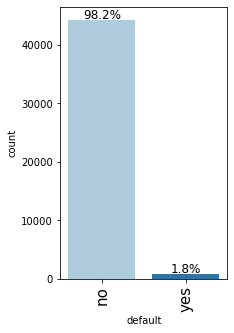

```python
labeled_barplot(df, "default", perc=True)
```

98.2% of the customers are not defaulters for a loan

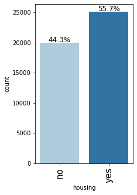

```python
labeled_barplot(df, "housing", perc=True)
```

Around 55.7% of the customers take out housing loans

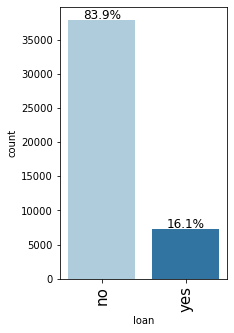

```python
labeled_barplot(df, "loan", perc=True)
```

83.9% of the customers do not have personal loans

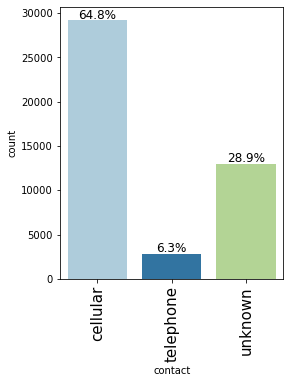

```python
labeled_barplot(df, "contact", perc=True)
```

Most of the customers are contacted via a cellurar channel

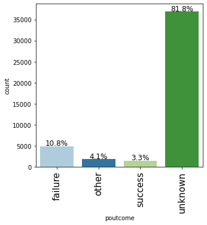

```python
labeled_barplot(df, "poutcome", perc=True)
```

The outcome for most of the customers is unkown

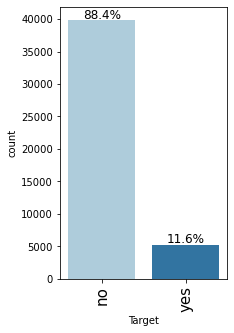

```python
labeled_barplot(df, "Target", perc=True)
```

11.6% is the success rate of converion in order to get the client subscribed to a term deposit

The plot also shows that the distribution of both classes is imbalanced

# Bivariative Analysis

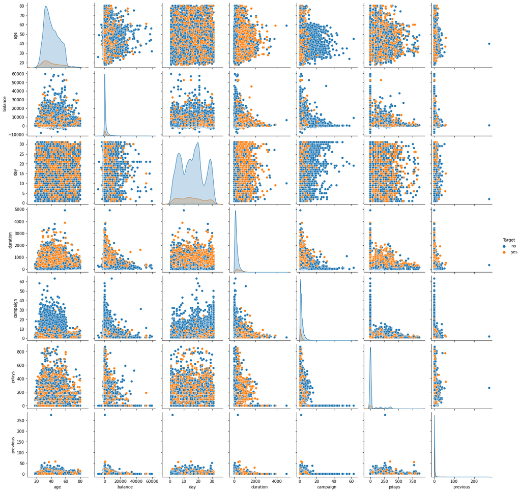

```python
sns.pairplot(data=df,hue='Target')
```

# Defining Functions

```python
def stacked_barplot(data, predictor, target):
    """
    Print the category counts and plot a stacked bar chart

    data: dataframe
    predictor: independent variable
    target: target variable
    """
    count = data[predictor].nunique()
    sorter = data[target].value_counts().index[-1]
    tab1 = pd.crosstab(data[predictor], data[target], margins=True).sort_values(
        by=sorter, ascending=False
    )
    print(tab1)
    print("-" * 120)
    tab = pd.crosstab(data[predictor], data[target], normalize="index").sort_values(
        by=sorter, ascending=False
    )
    tab.plot(kind="bar", stacked=True, figsize=(count + 1, 5))
    plt.legend(
        loc="lower left",
        frameon=False,
    )
    plt.legend(loc="upper left", bbox_to_anchor=(1, 1))
    plt.show()
```

# Form of contact vs term deposit taken

```
Target         0     1    All
contact
All        39860  5246  45106
cellular   24888  4352  29240
unknown    12490   530  13020
telephone   2482   364   2846
------------------------------------------------------------------------------------------------------------------------
```

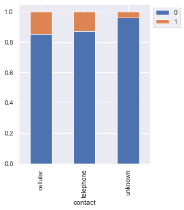

```python
stacked_barplot(df, "contact", "Target" )
```

The conversion rate of the people contatced via cellular support is the highest.